# 2020MCS120003_MiniProject

Amith CA

04/10/2020

# COVID - 19

Coronavirus disease (COVID-19) is an infectious disease caused by a newly discovered coronavirus.

Most people infected with the COVID-19 virus will experience mild to moderate respiratory illness and recover without requiring special treatment. Older people, and those with underlying medical problems like cardiovascular disease, diabetes, chronic respiratory disease, and cancer are more likely to develop serious illness.

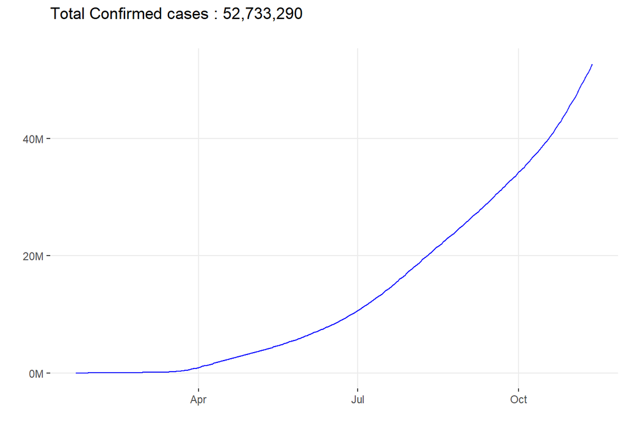

Newly confirmed cases:  
606,497 ↑

### Worldwide Data

Globally, as of 12-Nov-2020, there have been 52,733,290 confirmed cases of COVID-19, including 1,293,183 deaths, reported.

There are 606,497 newly confirmed cases and 9,020 new deaths.

Source: https://raw.githubusercontent.com/CSSEGISandData/COVID-19/

| ACTIVE CASES | DEATHS | RECOVERED CASES |
| --- | --- | --- |
| 17,290,884 | 1,293,183 | 34,149,223 |
| ↑ 374,605 | ↑ 9,020 | ↑ 222,872 |

### Active cases:

From the source dataset the total number of confirmed cases,the total deaths and the total number of recovered cases of a country/province as of 12-Nov-2020,is readily available. By reducing the sum of death and recovered cases from the total number of cases on a day. We will be able to find the total number of active cases in the Country/province till that day. Given below is a plot of the total number of active cases in a country / province.  
The places with the number of active cases above 10,00,000 are plotted using red markers. The places with active count between 1000 and 10,00,000 are plotted using the orange markers. The places with the number of active cases less than 1000 are plotted using the blue markers.  
The number of active cases of a country/province can be viewed by clicked on the marker in the map.

[interactive chart not shown]

### Top 10 Countries based on Active cases:

The below list shows the top 10 countries with the most number of active cases as of 12-Nov-2020.  
The newly reported death, confirmed cases and recovered is calculated by subtracting the total count of the previous day with the current count.

|  | Country | Total Confirmed | Total Death | Total Recovered | Total Active | Newly Confirmed | New Deaths | Death ratio | Recovered ratio |
| --- | --- | --- | --- | --- | --- | --- | --- | --- | --- |
| 1 | US | 10552821 | 242423 | 4051256 | 6259142 | 153496 | 919 | 0.023 | 0.3839 |
| 2 | France | 1915282 | 42599 | 139212 | 1733471 | 364 | 0 | 0.0222 | 0.0727 |
| 3 | Spain | 1437220 | 40461 | 150376 | 1246383 | 19511 | 356 | 0.0282 | 0.1046 |
| 4 | United Kingdom | 1293715 | 51020 | 3031 | 1239664 | 33517 | 563 | 0.0394 | 0.0023 |
| 5 | Italy | 1066401 | 43589 | 387758 | 635054 | 37977 | 636 | 0.0409 | 0.3636 |
| 6 | Belgium | 520393 | 13891 | 0 | 506502 | 5002 | 133 | 0.0267 | 0 |
| 7 | India | 8728795 | 128668 | 8115580 | 484547 | 44879 | 547 | 0.0147 | 0.9297 |
| 8 | Russia | 1843678 | 31755 | 1378463 | 433460 | 21333 | 429 | 0.0172 | 0.7477 |
| 9 | Netherlands | 437376 | 8375 | 6372 | 422629 | 5680 | 89 | 0.0191 | 0.0146 |
| 10 | Poland | 641496 | 9080 | 254349 | 378067 | 22683 | 275 | 0.0142 | 0.3965 |

[output cut: 177 more lines]

The death ratio in the above table represents the ratio of total number of deaths to total number of confirmed cases.  
The recovered ratio in the above table represents the ratio of total number of recovered cases to total number of confirmed cases.

### Confirmed cases plot

A Plot of increase in confirmed cases in the countries with most number of active cases. From the graph we can find the increase number of confirmed cases in country.

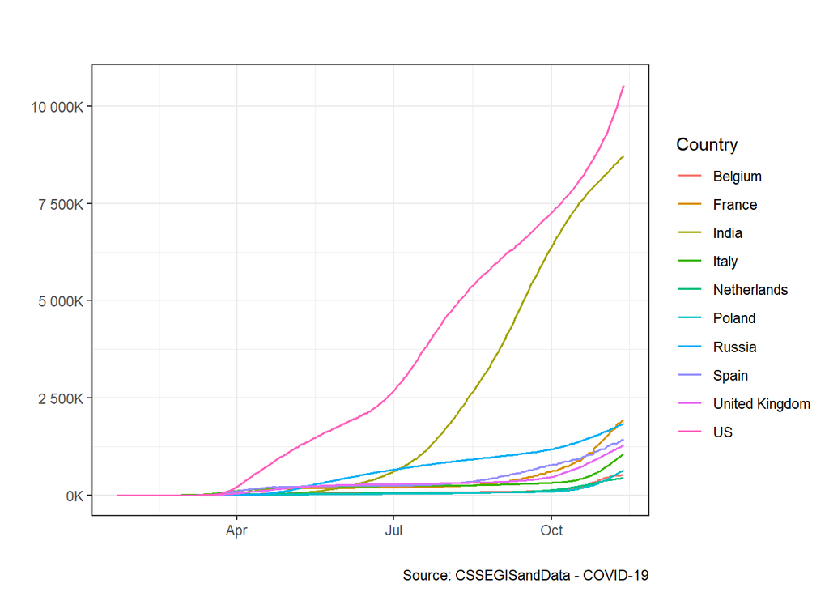

### Comparison of the number of daily deaths reported

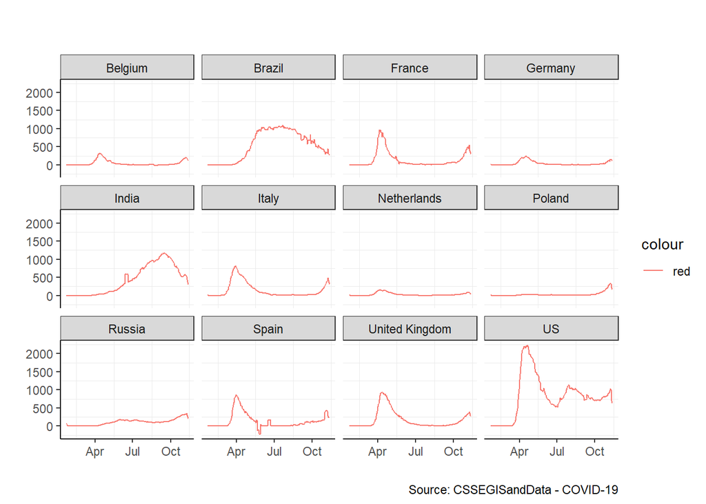

### The date at which the first confirmed case was found in a country province.

|  | Country | Province | FirstConfirmed |
| --- | --- | --- | --- |
| 1 | China | Anhui | 2020-01-22 |
| 2 | China | Beijing | 2020-01-22 |
| 3 | China | Chongqing | 2020-01-22 |
| 4 | China | Fujian | 2020-01-22 |
| 5 | China | Guangdong | 2020-01-22 |
| 6 | China | Guangxi | 2020-01-22 |
| 7 | China | Guizhou | 2020-01-22 |
| 8 | China | Hainan | 2020-01-22 |
| 9 | China | Hebei | 2020-01-22 |
| 10 | China | Henan | 2020-01-22 |

[output cut: 259 more lines]

### Additional inferences:

# INDIA

So far, India has recorded 8,728,795 confirmed COVID-19 cases, including 128,668 deaths. A total of 8,115,580 people have recuperated from COVID-19 so far. There are 484,547 active cases in the country as of date, which comprise 5.551133% percent of the total caseload, the data stated.

Government of INDIA Ministry of Health and Family Welfare official website: https://www.mohfw.gov.in/

### COVID-19 data : India

A Plot of change in confirmed cases,recovered cases,active cases, deaths in India

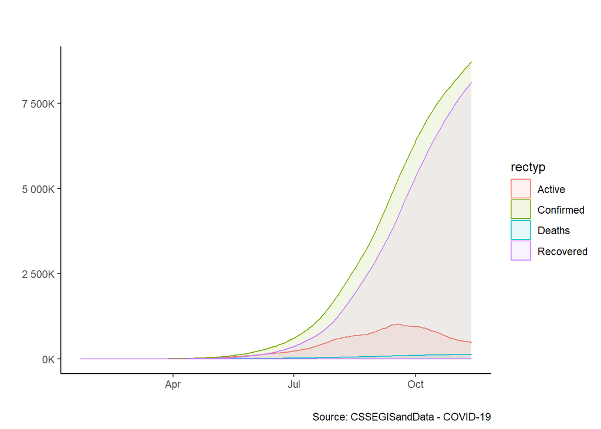

### Death to Confirmed ratio plot

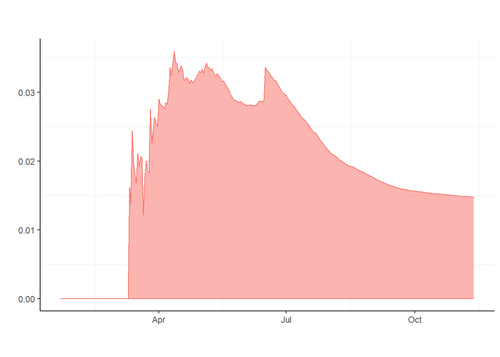

### Plot of the daily reported confirmed and death count in India

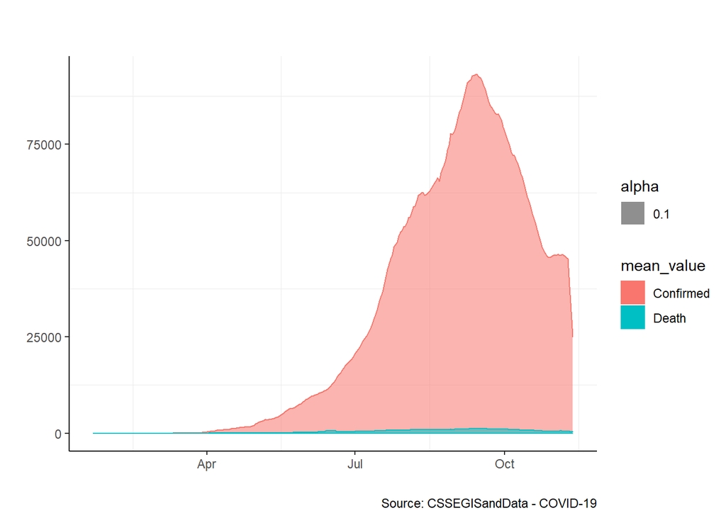

The maximum number of confirmed cases reported on a single day in India is 93,199 on 13-Sep-2020.

### Confimed cases plot in India’s neighbouring countries

A comparison of confirmed cases increase in India’s neighbouring countries.

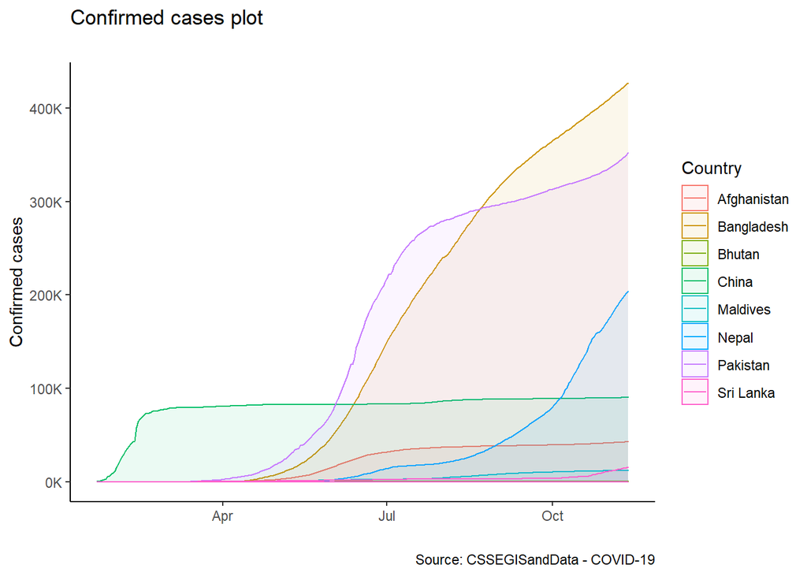

### Deaths to confirmed count of India and its neighbours.

The below graph shows the death to confirmed ratio of India and its neighboring countries.

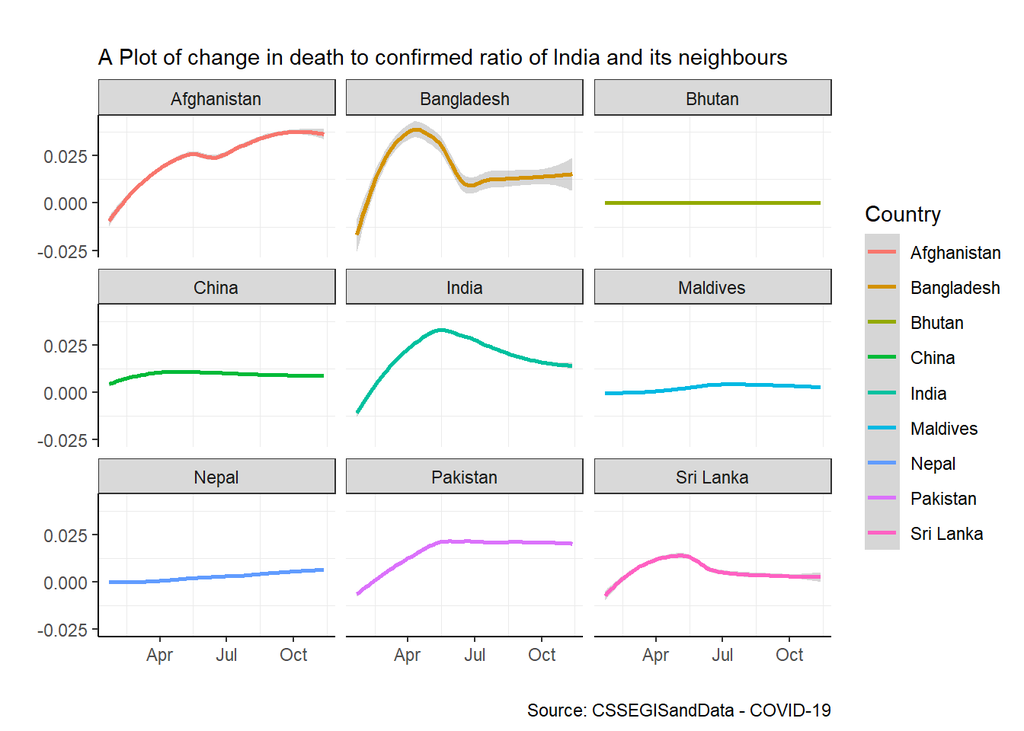

### Symptoms

Symptoms of COVID-19 may appear in as few as 2 days or as long as 14 (estimated ranges vary from 2-10 days, 2-14 days, and 10-14 days), during which the virus is contagious but the patient does not display any symptom (asymptomatic transmission).

COVID-19 affects different people in different ways. Most infected people will develop mild to moderate illness and recover without hospitalization.

Most common symptoms

Less common symptoms

Serious symptoms CASES

- Fever
- Dry cough
- Tiredness
- Aches and pains
- Sore throat
- Diarrhoea
- Conjunctivitis
- Headache
- Loss of taste or smell
- A rash on skin, or discolouration of fingers or toes
- Difficulty breathing or shortness of breath
- Chest pain or pressure
- Loss of speech or movement

Seek immediate medical attention if you have serious symptoms. Always call before visiting your doctor or health facility.  
People with mild symptoms who are otherwise healthy should manage their symptoms at home.  
On average it takes 5–6 days from when someone is infected with the virus for symptoms to show, however it can take up to 14 days.

### Tips to Prevent the spread of Corona virus:

To prevent infection and to slow transmission of COVID-19, do the following:

- Wash your hands regularly with soap and water, or clean them with alcohol-based hand rub.
- Maintain at least 1 metre distance between you and people coughing or sneezing.
- Avoid touching your face.
- Cover your mouth and nose when coughing or sneezing.
- Stay home if you feel unwell.
- Refrain from smoking and other activities that weaken the lungs.
- Practice physical distancing by avoiding unnecessary travel and staying away from large groups of people.